# Supervised Learning Assignment: Random Forest

Sohana Sadique

2026-03-12

```r
knitr::opts_chunk$set(echo = TRUE)
library(tidyverse)
library(tidymodels)
```

```r
library(sjPlot)
library(C50)
library(ranger)
library(finalfit)
library(knitr)
library(gtsummary)
library(mlbench)
library(vip)
library(rsample)
library(rpart.plot)
library(tune)
library(recipes)
library(yardstick)
library(parsnip)
library(glmnet)
library(themis)
library(microbenchmark)
library(corrr)
library(tableone)
```

## Loading the dataset

For this assignmnet I am using the CanPath imputed dataset.

```r
data <-read_csv("C:/Users/Sohana/OneDrive - University of Saskatchewan/ML 898/data/canpath_imputed.csv")
```

## Inspecting the structure of the dataset

```r
#str(data)
#skimr::skim(data)
```

*Interpretation:* The dataset has 41,187 observations and 93 variables. There are no missing values in the dataset. The variables are a mix of numeric and factor variables. The first two variables, `ID` and `ADM_STUDY_ID`, are likely identifiers for the participants and can be removed from the dataset as they do not provide any predictive value for the outcome variable.

## Research Question for this assignmnet

**Can we develop a model that will predict whether a participant has ever had depression?**

## Conversion to factors and selecting variables

Here I am organizing data to run our models.

```r
data <- data %>%
  mutate(across(c(3,5:6,8:12,15:81,83:91), as.factor))

data$ID <- NULL
data$ADM_STUDY_ID <- NULL
```

## Checking the structure of the dataset again to confirm that all variables are coded to their accurate types.

```r
#str(data)
```

## Selecting and recoding variables

Based on my research question my outcome variables is : *DIS_DEP_EVER*: Occurrence of major depression at any point during the life of the participant.

Predictors : *SDC_AGE_CALC, SDC_GENDER, SDC_MARITAL_STATUS, SDC_EDU_LEVEL, SDC_INCOME, SDC_HOUSEHOLD_ADULTS_NB, SDC_HOUSEHOLD_CHILDREN_NB, DIS_DIAB_EVER, PA_TOTAL_SHORT, PM_BMI_SR, ALC_EVER, SMK_CIG_EVER, HS_GEN_HEALTH, WRK_EMPLOYMENT, DIS_DEP_FAM_EVER, DIS_MH_ANXIETY_EVER*

## Simplifying the data

Here I am simplifying the data because the random forest model can be computationally expensive, and I want to make sure that the model runs in a reasonable amount of time. I will select only the variables that are relevant to my research question and that I think will be good predictors of the outcome variable.

```r
data_small <- select(data, DIS_DEP_EVER, SDC_AGE_CALC, SDC_GENDER, SDC_MARITAL_STATUS, SDC_EDU_LEVEL, SDC_INCOME, SDC_HOUSEHOLD_ADULTS_NB, SDC_HOUSEHOLD_CHILDREN_NB, DIS_DIAB_EVER, PA_TOTAL_SHORT, PM_BMI_SR, ALC_EVER, SMK_CIG_EVER, HS_GEN_HEALTH, WRK_EMPLOYMENT, DIS_DEP_FAM_EVER, DIS_MH_ANXIETY_EVER)
```

## Preparing dataset

### Depression

```r
table(data_small$DIS_DEP_EVER)
```

```
##
##     0     1     2
## 34796  5136  1255
```

```r
data_small <- data_small %>%
    mutate(depression = case_when(
        DIS_DEP_EVER == 0 ~ "No",
        DIS_DEP_EVER == 1 ~ "Yes",
        DIS_DEP_EVER == 2 ~ "No"))

table(data_small$DIS_DEP_EVER, data_small$depression)
```

```
##
##        No   Yes
##   0 34796     0
##   1     0  5136
##   2  1255     0
```

```r
data_small$DIS_DEP_EVER <- NULL
```

### Gender

```r
table(data_small$SDC_GENDER)
```

```
##
##     1     2
## 15200 25987
```

```r
data_small <- data_small %>%
    mutate(gender = case_when(
        SDC_GENDER == 1 ~ "Male",
        SDC_GENDER == 2 ~ "Female"))

table(data_small$SDC_GENDER, data_small$gender)
```

```
##
##     Female  Male
##   1      0 15200
##   2  25987     0
```

```r
data_small$SDC_GENDER <- NULL
```

### Marital Status

```r
table(data_small$SDC_MARITAL_STATUS)
```

```
##
##     1     2     3     4     5
## 30651  3595  1192  1555  4194
```

```r
data_small <- data_small %>%
            mutate(marital_recode = case_when(
                                SDC_MARITAL_STATUS == 1 ~ "1_Married and/or living with a partner",
                                SDC_MARITAL_STATUS == 2 ~ "2_Divorced",
                                SDC_MARITAL_STATUS == 3 ~ "3_Widowed",
                                SDC_MARITAL_STATUS == 4 ~ "4_Separated",
                                SDC_MARITAL_STATUS == 5 ~ "5_Single, never married"
            ))

table(data_small$SDC_MARITAL_STATUS, data_small$marital_recode)
```

```
##
##     1_Married and/or living with a partner 2_Divorced 3_Widowed 4_Separated
##   1                                  30651          0         0           0
##   2                                      0       3595         0           0
##   3                                      0          0      1192           0
##   4                                      0          0         0        1555
##   5                                      0          0         0           0
##
##     5_Single, never married
##   1                       0
##   2                       0
##   3                       0
##   4                       0
##   5                    4194
```

```r
data_small$SDC_MARITAL_STATUS <- NULL
```

### Education

```r
table(data_small$SDC_EDU_LEVEL)
```

```
##
##     0     1     2     3     4     5     6     7
##    79   565  7809  3486 10175  1795 11010  6268
```

```r
data_small <- data_small %>%
    mutate(edu_recode = case_when(
        SDC_EDU_LEVEL == 0 ~ "1_None",
        SDC_EDU_LEVEL == 1 ~ "2_Elementary School",
        SDC_EDU_LEVEL == 2 ~ "3_High School",
        SDC_EDU_LEVEL == 3 ~ "4_Trade, technical or vocational school",
        SDC_EDU_LEVEL == 4 ~ "5_Community college, CEGEP or non-university certificate",
        SDC_EDU_LEVEL == 5 ~ "6_University certificate below bachelor's level",
        SDC_EDU_LEVEL == 6 ~ "7_Bachelor's degree",
        SDC_EDU_LEVEL == 7 ~ "8_Graduate degree"))

table(data_small$SDC_EDU_LEVEL, data_small$edu_recode)
```

```
##
##     1_None 2_Elementary School 3_High School
##   0     79                   0             0
##   1      0                 565             0
##   2      0                   0          7809
##   3      0                   0             0
##   4      0                   0             0
##   5      0                   0             0
##   6      0                   0             0
##   7      0                   0             0
##
##     4_Trade, technical or vocational school
##   0                                       0
##   1                                       0
##   2                                       0
```

[output cut: 35 more lines]

```r
data_small$SDC_EDU_LEVEL <- NULL
```

### Income

```r
table(data_small$SDC_INCOME)
```

```
##
##    1    2    3    4    5    6    7    8
##  574 2447 6815 8008 7667 8826 3965 2885
```

```r
data_small <- data_small %>%
    mutate(income = case_when(
        SDC_INCOME == 1 ~ "1_<$50,000",
        SDC_INCOME == 2 ~ "1_<$50,000",
        SDC_INCOME == 3 ~ "1_<$50,000",
        SDC_INCOME == 4 ~ "2_$50,000 to $74,999",
        SDC_INCOME == 5 ~ "3_$75,000 to $99,999",
        SDC_INCOME == 6 ~ "4_$100,000 to $149,999",
        SDC_INCOME == 7 ~ "5_>150,000",
        SDC_INCOME == 8 ~ "5_>150,000"))

table(data_small$SDC_INCOME, data_small$income)
```

```
##
##     1_<$50,000 2_$50,000 to $74,999 3_$75,000 to $99,999 4_$100,000 to $149,999
##   1        574                    0                    0                      0
##   2       2447                    0                    0                      0
##   3       6815                    0                    0                      0
##   4          0                 8008                    0                      0
##   5          0                    0                 7667                      0
##   6          0                    0                    0                   8826
##   7          0                    0                    0                      0
##   8          0                    0                    0                      0
##
##     5_>150,000
##   1          0
##   2          0
##   3          0
##   4          0
##   5          0
##   6          0
##   7       3965
##   8       2885
```

```r
data_small$SDC_INCOME <- NULL
```

### Household Adults

```r
table(data_small$SDC_HOUSEHOLD_ADULTS_NB)
```

```
##
##     1     2     3     4     5     6     7     8    21
##  8140 25083  5294  2137   440    61    21    10     1
```

```r
data_small <- data_small %>%
    mutate(hh_adults = case_when(
        SDC_HOUSEHOLD_ADULTS_NB == 0 ~ "0",
        SDC_HOUSEHOLD_ADULTS_NB == 1 ~ "1",
        SDC_HOUSEHOLD_ADULTS_NB == 2 ~ "2",
        SDC_HOUSEHOLD_ADULTS_NB == 3 ~ "3",
        SDC_HOUSEHOLD_ADULTS_NB == 4 ~ "4+"))

table(data_small$SDC_HOUSEHOLD_ADULTS_NB, data_small$hh_adults)
```

```
##
##          1     2     3    4+
##   1   8140     0     0     0
##   2      0 25083     0     0
##   3      0     0  5294     0
##   4      0     0     0  2137
##   5      0     0     0     0
##   6      0     0     0     0
##   7      0     0     0     0
##   8      0     0     0     0
##   21     0     0     0     0
```

```r
data_small$SDC_HOUSEHOLD_ADULTS_NB <- NULL
```

### Household Children

```r
table(data_small$SDC_HOUSEHOLD_CHILDREN_NB)
```

```
##
##     0     1     2     3     4     5     6     7     9    10
## 28200  5667  5448  1490   305    51    11    10     4     1
```

```r
data_small <- data_small %>%
    mutate(hh_children = case_when(
        SDC_HOUSEHOLD_CHILDREN_NB == 0 ~ "0",
        SDC_HOUSEHOLD_CHILDREN_NB == 1 ~ "1",
        SDC_HOUSEHOLD_CHILDREN_NB == 2 ~ "2",
        SDC_HOUSEHOLD_CHILDREN_NB == 3 ~ "3+"))

table(data_small$SDC_HOUSEHOLD_CHILDREN_NB, data_small$hh_children)
```

```
##
##          0     1     2    3+
##   0  28200     0     0     0
##   1      0  5667     0     0
##   2      0     0  5448     0
##   3      0     0     0  1490
##   4      0     0     0     0
##   5      0     0     0     0
##   6      0     0     0     0
##   7      0     0     0     0
##   9      0     0     0     0
##   10     0     0     0     0
```

```r
data_small$SDC_HOUSEHOLD_CHILDREN_NB <- NULL
```

### Diabetes

```r
table(data_small$DIS_DIAB_EVER)
```

```
##
##     0     1     2
## 36714  3114  1359
```

```r
data_small <- data_small %>%
    mutate(diabetes = case_when(
        DIS_DIAB_EVER == 0 ~ "No",
        DIS_DIAB_EVER == 1 ~ "Yes",
        DIS_DIAB_EVER == 2 ~ "No"))

table(data_small$DIS_DIAB_EVER, data_small$diabetes)
```

```
##
##        No   Yes
##   0 36714     0
##   1     0  3114
##   2  1359     0
```

```r
data_small$DIS_DIAB_EVER <- NULL
```

### Alcohol

```r
table(data_small$ALC_EVER)
```

```
##
##     0     1
##  2453 38734
```

```r
data_small <- data_small %>%
    mutate(alcohol = case_when(
        ALC_EVER == 0 ~ "No",
        ALC_EVER == 1 ~ "Yes",
        ALC_EVER == 2 ~ "No"))

table(data_small$ALC_EVER, data_small$alcohol)
```

```
##
##        No   Yes
##   0  2453     0
##   1     0 38734
```

```r
data_small$ALC_EVER <- NULL
```

### Smoking

```r
table(data_small$SMK_CIG_EVER)
```

```
##
##     0     1
## 22255 18932
```

```r
data_small <- data_small %>%
    mutate(smoking = case_when(
        SMK_CIG_EVER == 0 ~ "No",
        SMK_CIG_EVER == 1 ~ "Yes",
        SMK_CIG_EVER == 2 ~ "No"))

table(data_small$SMK_CIG_EVER, data_small$smoking)
```

```
##
##        No   Yes
##   0 22255     0
##   1     0 18932
```

```r
data_small$SMK_CIG_EVER <- NULL
```

### General Health

```r
table(data_small$HS_GEN_HEALTH)
```

```
##
##     1     2     3     4     5
##   832  3377 12783 17183  7012
```

```r
data_small <- data_small %>%
    mutate(health_recode = case_when(
        HS_GEN_HEALTH == 1 ~ "1_Excellent",
        HS_GEN_HEALTH == 2 ~ "1_Excellent",
        HS_GEN_HEALTH == 3 ~ "2_Very_Good",
        HS_GEN_HEALTH == 4 ~ "3_Good",
        HS_GEN_HEALTH == 5 ~ "4_Fair"))

table(data_small$HS_GEN_HEALTH, data_small$health_recode)
```

```
##
##     1_Excellent 2_Very_Good 3_Good 4_Fair
##   1         832           0      0      0
##   2        3377           0      0      0
##   3           0       12783      0      0
##   4           0           0  17183      0
##   5           0           0      0   7012
```

```r
data_small$HS_GEN_HEALTH <- NULL
```

### Employment

```r
table(data_small$WRK_EMPLOYMENT)
```

```
##
##     0     1
## 12649 28538
```

```r
data_small <- data_small %>%
    mutate(employment_recode = case_when(
        WRK_EMPLOYMENT == 1 ~ "Employed",
        WRK_EMPLOYMENT == 0 ~ "Unempyloyed"))

table(data_small$WRK_EMPLOYMENT, data_small$employment_recode)
```

```
##
##     Employed Unempyloyed
##   0        0       12649
##   1    28538           0
```

```r
data_small$WRK_EMPLOYMENT <- NULL
```

### Family history of depression

```r
table(data_small$DIS_DEP_FAM_EVER)
```

```
##
##     0     1     2
## 17465 11278 12444
```

```r
data_small <- data_small %>%
    mutate(dep_fam_recode = case_when(
        DIS_DEP_FAM_EVER == 0 ~ "No",
        DIS_DEP_FAM_EVER == 1 ~ "Yes",
        DIS_DEP_FAM_EVER == 2 ~ "No"))

table(data_small$DIS_DEP_FAM_EVER, data_small$dep_fam_recode)
```

```
##
##        No   Yes
##   0 17465     0
##   1     0 11278
##   2 12444     0
```

```r
data_small$DIS_DEP_FAM_EVER <- NULL
```

### Anxiety

```r
table(data_small$DIS_MH_ANXIETY_EVER)
```

```
##
##     0     1     2
## 35223  5197   767
```

```r
data_small <- data_small %>%
    mutate(anxiety_recode = case_when(
        DIS_MH_ANXIETY_EVER == 0 ~ "No",
        DIS_MH_ANXIETY_EVER == 1 ~ "Yes",
        DIS_MH_ANXIETY_EVER == 2 ~ "No"))

table(data_small$DIS_MH_ANXIETY_EVER, data_small$anxiety_recode)
```

```
##
##        No   Yes
##   0 35223     0
##   1     0  5197
##   2   767     0
```

```r
data_small$DIS_MH_ANXIETY_EVER <- NULL
```

## 1. Dataset Exploration

### Summary Statistics after cleaning

```r
vars <- c(
"SDC_AGE_CALC",
"gender",
"marital_recode",
"edu_recode",
"income",
"hh_adults",
"hh_children",
"diabetes",
"PM_BMI_SR",
"alcohol",
"smoking",
"health_recode",
"employment_recode",
"dep_fam_recode",
"anxiety_recode",
"PA_TOTAL_SHORT"
)
```

### Table 1: Summary of participant characteristics stratified by depression status

```r
table1 <- CreateTableOne(
vars = vars,
strata = "depression",
data = data_small)

print(table1, showAllLevels = TRUE)
```

```
##                             Stratified by depression
##                              level
##   n
##   SDC_AGE_CALC (mean (SD))
##   gender (%)                 Female
##                              Male
##   marital_recode (%)         1_Married and/or living with a partner
##                              2_Divorced
##                              3_Widowed
##                              4_Separated
##                              5_Single, never married
##   edu_recode (%)             1_None
##                              2_Elementary School
##                              3_High School
##                              4_Trade, technical or vocational school
##                              5_Community college, CEGEP or non-university certificate
##                              6_University certificate below bachelor's level
##                              7_Bachelor's degree
##                              8_Graduate degree
##   income (%)                 1_<$50,000
##                              2_$50,000 to $74,999
##                              3_$75,000 to $99,999
##                              4_$100,000 to $149,999
##                              5_>150,000
##   hh_adults (%)              1
##                              2
##                              3
##                              4+
##   hh_children (%)            0
##                              1
##                              2
##                              3+
##   diabetes (%)               No
##                              Yes
##   PM_BMI_SR (mean (SD))
##   alcohol (%)                No
##                              Yes
##   smoking (%)                No
##                              Yes
##   health_recode (%)          1_Excellent
```

[output cut: 45 more lines]

```
##   alcohol (%)                   2092 ( 5.8)        361 ( 7.0)     0.001
##                                33959 (94.2)       4775 (93.0)
##   smoking (%)                  19759 (54.8)       2496 (48.6)    <0.001
##                                16292 (45.2)       2640 (51.4)
##   health_recode (%)             3105 ( 8.6)       1104 (21.5)    <0.001
##                                10956 (30.4)       1827 (35.6)
##                                15576 (43.2)       1607 (31.3)
##                                 6414 (17.8)        598 (11.6)
##   employment_recode (%)        25195 (69.9)       3343 (65.1)    <0.001
##                                10856 (30.1)       1793 (34.9)
##   dep_fam_recode (%)           27222 (75.5)       2687 (52.3)    <0.001
##                                 8829 (24.5)       2449 (47.7)
##   anxiety_recode (%)           32652 (90.6)       3338 (65.0)    <0.001
##                                 3399 ( 9.4)       1798 (35.0)
##   PA_TOTAL_SHORT (mean (SD)) 2603.00 (2689.71) 2630.86 (2706.64)  0.488
```

*Interpretation:* Table 1 summarizes participant characteristics stratified by depression status. A total of 41,187 participants were included in the analysis, of whom 5,136 (12.5%) reported depression and 36,051 (87.5%) did not. Individuals with depression were slightly older on average (51.8 ± 10.7 years) compared with those without depression (51.4 ± 10.8 years, p = 0.015). A higher proportion of participants with depression were female (3,868; 75.3%) compared with the non-depressed group (22,119; 61.4%, p < 0.001). Participants with depression were also less likely to be married or living with a partner (65.0% vs. 75.8%) and more likely to report lower household income, particularly incomes below $50,000 (31.0% vs. 22.9%, p < 0.001).

### Correlations

```
## Non-numeric variables removed from input: `depression`, `gender`, `marital_recode`, `edu_recode`, `income`, `hh_adults`, `hh_children`, `diabetes`, `alcohol`, `smoking`, `health_recode`, `employment_recode`, `dep_fam_recode`, and `anxiety_recode`
## Correlation computed with
## • Method: 'pearson'
## • Missing treated using: 'pairwise.complete.obs'
```

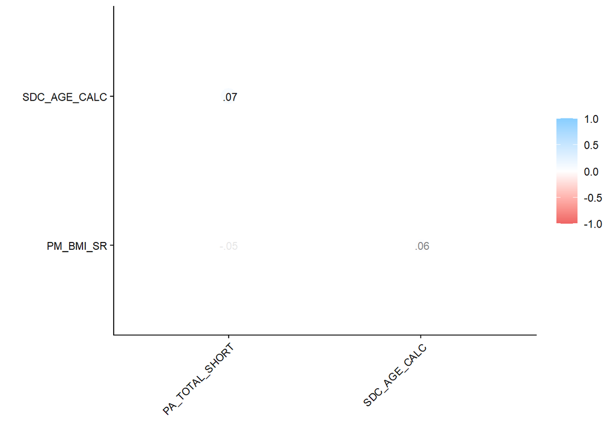

```r
data_small %>%
  correlate() %>%
  rearrange() %>%
  shave()  %>%
  rplot(print_cor=TRUE) +
   theme(axis.text.x = element_text(angle = 45, hjust = 1))
```

*Interpretation:* Overall, there are no strong correlations that would suggest multicollinearity issues in the dataset.

### Outcome distribution

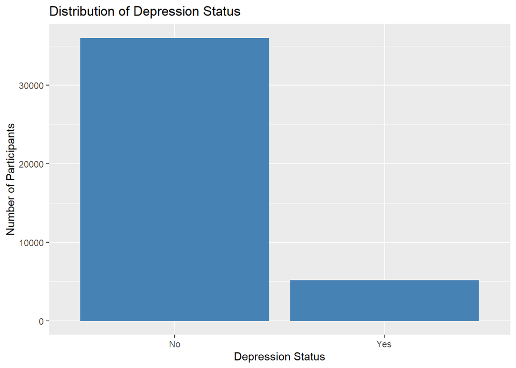

```r
ggplot(data_small, aes(x = depression)) +
  geom_bar(fill = "steelblue") +
  labs(
    title = "Distribution of Depression Status",
    x = "Depression Status",
    y = "Number of Participants"
  )
```

*Interpretation:* The bar plot shows that the majority of participants in the dataset have never had depression, while a smaller proportion have experienced depression at some point in their lives. This indicates an imbalance in the outcome variable, which may need to be addressed during model training to ensure that the model does not become biased towards predicting the majority class.

### Age distribution by depression status

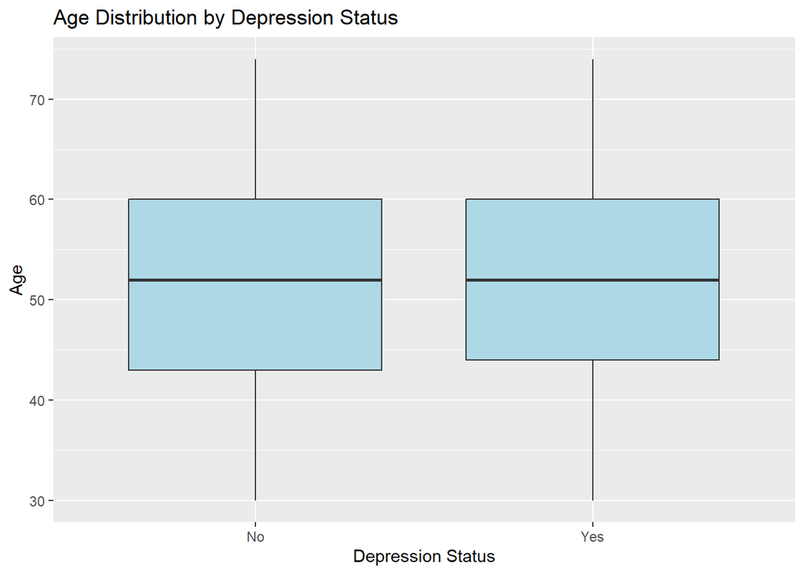

```r
ggplot(data_small, aes(x = depression, y = SDC_AGE_CALC)) +
  geom_boxplot(fill = "lightblue") +
  labs(
    title = "Age Distribution by Depression Status",
    x = "Depression Status",
    y = "Age"
  )
```

### BMI vs Physical Activity, colored by depression status

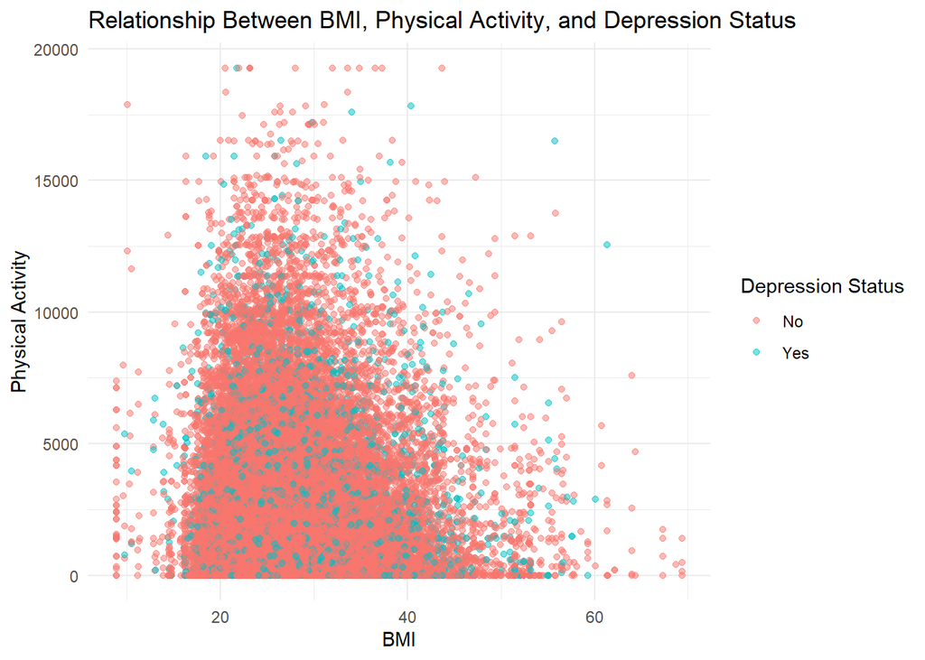

```r
ggplot(data_small, aes(x = PM_BMI_SR, y = PA_TOTAL_SHORT, color = depression)) +
  geom_point(alpha = 0.5) +
  labs(
    title = "Relationship Between BMI, Physical Activity, and Depression Status",
    x = "BMI",
    y = "Physical Activity",
    color = "Depression Status"
  ) +
  theme_minimal()
```

*Interpretation:* The scatter plot shows the relationship between BMI, physical activity, and depression status. There is a wide range of BMI and physical activity levels in both groups. However, there does not appear to be a clear pattern or strong relationship between these variables and depression status. Both groups have individuals with low and high BMI, as well as low and high physical activity levels, suggesting that these factors alone may not be strong predictors of depression in this dataset.

## 2. Baseline Random Forest Model

```r
set.seed(10)

cv_split <- initial_validation_split(data_small,
                            strata = depression,
                            prop = c(0.70, 0.20))

train_data <- training(cv_split)
table(train_data$depression)
```

```
##
##    No   Yes
## 25235  3595
```

```r
test_data  <- testing(cv_split)
table(test_data$depression)
```

```
##
##   No  Yes
## 3599  520
```

The distribution of the outcome variable (depression) is similar in both sets.

```r
cores <- parallel::detectCores()
cores
```

```
## [1] 16
```

## Baseline model

```r
rf_baseline <- rand_forest(
  mtry = 4,
  min_n = 5,
  trees = 100
) %>%
  set_engine("ranger", num.threads = cores) %>%
  set_mode("classification")
```

The baseline random forest model was fitted using fixed hyperparameters (mtry = 4, min_n = 5, and trees = 100). The value of mtry was chosen based on the common rule of thumb for classification random forests, where the number of predictors considered at each split is approximately the square root of the total number of predictors. The value of min_n = 5 was used as a standard setting to prevent overly small node splits and reduce overfitting.

### Recipe

```r
depression_recipe_baseline <-
  recipe(depression ~ ., data = train_data) %>%
  step_zv(all_predictors())
```

### Workflow

```r
depression_workflow_baseline <-
        workflow() %>%
        add_model(rf_baseline) %>%
        add_recipe(depression_recipe_baseline)
depression_workflow_baseline
```

```
## ══ Workflow ════════════════════════════════════════════════════════════════════
## Preprocessor: Recipe
## Model: rand_forest()
##
## ── Preprocessor ────────────────────────────────────────────────────────────────
## 1 Recipe Step
##
## • step_zv()
##
## ── Model ───────────────────────────────────────────────────────────────────────
## Random Forest Model Specification (classification)
##
## Main Arguments:
##   mtry = 4
##   trees = 100
##   min_n = 5
##
## Engine-Specific Arguments:
##   num.threads = cores
##
## Computational engine: ranger
```

### Fit the model

```r
set.seed(100)

baseline_fit <- depression_workflow_baseline %>%
  last_fit(cv_split)
```

### Matrics

```r
collect_metrics(baseline_fit)
```

```
## # A tibble: 3 × 4
##   .metric     .estimator .estimate .config
##   <chr>       <chr>          <dbl> <chr>
## 1 accuracy    binary        0.877  pre0_mod0_post0
## 2 roc_auc     binary        0.749  pre0_mod0_post0
## 3 brier_class binary        0.0971 pre0_mod0_post0
```

```r
baseline_pred <- collect_predictions(baseline_fit)

conf_mat(baseline_pred, truth = depression, estimate = .pred_class)
```

```
##           Truth
## Prediction   No  Yes
##        No  3540  446
##        Yes   59   74
```

```r
accuracy(baseline_pred, truth = depression, estimate = .pred_class)
```

```
## # A tibble: 1 × 3
##   .metric  .estimator .estimate
##   <chr>    <chr>          <dbl>
## 1 accuracy binary         0.877
```

```r
sens(baseline_pred, truth = depression, estimate = .pred_class, event_level = "second")
```

```
## # A tibble: 1 × 3
##   .metric .estimator .estimate
##   <chr>   <chr>          <dbl>
## 1 sens    binary         0.142
```

```r
spec(baseline_pred, truth = depression, estimate = .pred_class, event_level = "second")
```

```
## # A tibble: 1 × 3
##   .metric .estimator .estimate
##   <chr>   <chr>          <dbl>
## 1 spec    binary         0.984
```

```r
f_meas(baseline_pred, truth = depression, estimate = .pred_class, event_level = "second")
```

```
## # A tibble: 1 × 3
##   .metric .estimator .estimate
##   <chr>   <chr>          <dbl>
## 1 f_meas  binary         0.227
```

```r
roc_auc(baseline_pred, truth = depression, .pred_Yes, event_level = "second")
```

```
## # A tibble: 1 × 3
##   .metric .estimator .estimate
##   <chr>   <chr>          <dbl>
## 1 roc_auc binary         0.749
```

*Interpretation:* The baseline random forest model achieved an accuracy of 0.877 and a ROC-AUC of 0.749, indicating moderate predictive performance. While the model demonstrated very high specificity (0.984) in identifying individuals without depression, it showed low sensitivity (0.142) for detecting depression cases. This suggests that the model is much better at correctly identifying non-depressed individuals than those with depression, which may be a concern given the importance of accurately identifying individuals with depression for potential interventions. The F1 score of 0.23 further indicates that the model’s performance in predicting the positive class (depression) is relatively poor. Overall, while the model performs well in terms of overall accuracy, it may not be effective for identifying individuals with depression, and further tuning or alternative modeling approaches may be needed to improve sensitivity.

### Forest model object

```r
rf_model <- rand_forest(mtry = tune(), min_n = tune(), trees = 100) %>%
              set_engine("ranger", num.threads = cores) %>%
              set_mode("classification")
```

### Receipe

```r
depression_recipe <-
  recipe(depression ~ ., data = train_data) %>%
  step_zv(all_predictors())
```

### Workflow

```r
depression_workflow <-
        workflow() %>%
        add_model(rf_model) %>%
        add_recipe(depression_recipe)

depression_workflow
```

```
## ══ Workflow ════════════════════════════════════════════════════════════════════
## Preprocessor: Recipe
## Model: rand_forest()
##
## ── Preprocessor ────────────────────────────────────────────────────────────────
## 1 Recipe Step
##
## • step_zv()
##
## ── Model ───────────────────────────────────────────────────────────────────────
## Random Forest Model Specification (classification)
##
## Main Arguments:
##   mtry = tune()
##   trees = 100
##   min_n = tune()
##
## Engine-Specific Arguments:
##   num.threads = cores
##
## Computational engine: ranger
```

### Fit a model

```r
set.seed(100)

folds <- vfold_cv(train_data, v = 10)

rf_grid <- grid_regular(
              mtry(range = c(2, 8)),
              min_n(range = c(5, 50)),
              levels = 5
            )

rf_grid
```

```
## # A tibble: 25 × 2
##     mtry min_n
##    <int> <int>
##  1     2     5
##  2     3     5
##  3     5     5
##  4     6     5
##  5     8     5
##  6     2    16
##  7     3    16
##  8     5    16
##  9     6    16
## 10     8    16
## # ℹ 15 more rows
```

```r
depression_fit <- tune_grid(
                depression_workflow,
                resamples = folds,
                grid = rf_grid,
                control = control_resamples(save_pred = TRUE,
                                                  verbose = FALSE))

depression_fit
```

```
## # Tuning results
## # 10-fold cross-validation
## # A tibble: 10 × 5
##    splits               id     .metrics          .notes           .predictions
##    <list>               <chr>  <list>            <list>           <list>
##  1 <split [25947/2883]> Fold01 <tibble [75 × 6]> <tibble [0 × 4]> <tibble>
##  2 <split [25947/2883]> Fold02 <tibble [75 × 6]> <tibble [0 × 4]> <tibble>
##  3 <split [25947/2883]> Fold03 <tibble [75 × 6]> <tibble [0 × 4]> <tibble>
##  4 <split [25947/2883]> Fold04 <tibble [75 × 6]> <tibble [0 × 4]> <tibble>
##  5 <split [25947/2883]> Fold05 <tibble [75 × 6]> <tibble [0 × 4]> <tibble>
##  6 <split [25947/2883]> Fold06 <tibble [75 × 6]> <tibble [0 × 4]> <tibble>
##  7 <split [25947/2883]> Fold07 <tibble [75 × 6]> <tibble [0 × 4]> <tibble>
##  8 <split [25947/2883]> Fold08 <tibble [75 × 6]> <tibble [0 × 4]> <tibble>
##  9 <split [25947/2883]> Fold09 <tibble [75 × 6]> <tibble [0 × 4]> <tibble>
## 10 <split [25947/2883]> Fold10 <tibble [75 × 6]> <tibble [0 × 4]> <tibble>
```

### Plot of the results

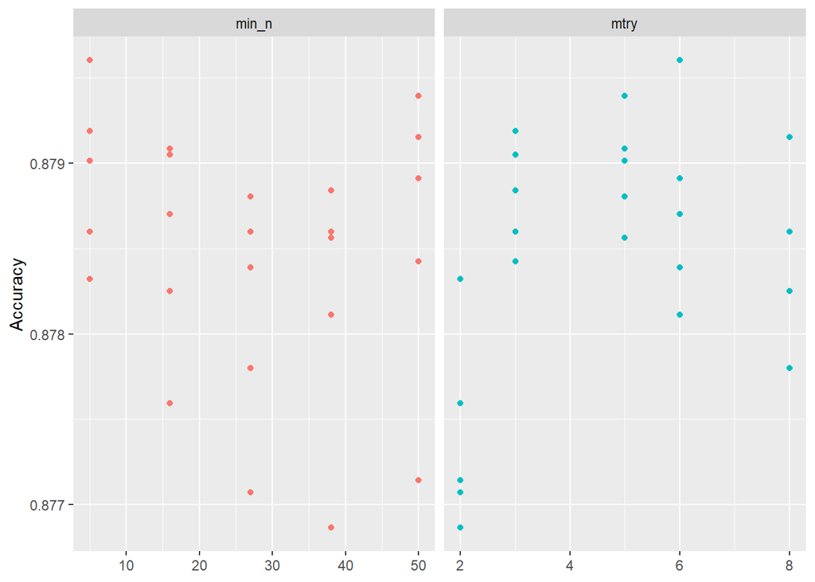

```r
depression_fit %>%
  collect_metrics() %>%
  filter(.metric == "accuracy") %>%
  select(mean, min_n, mtry) %>%
  pivot_longer(min_n:mtry,
    values_to = "value",
    names_to = "parameter"
  ) %>%
  ggplot(aes(value, mean, color = parameter)) +
  geom_point(show.legend = FALSE) +
  facet_wrap(~parameter, scales = "free_x") +
  labs(x = NULL, y = "Accuracy")
```

*Interpretation:* The hyperparameter tuning results show that model accuracy varied only slightly across different values of mtry and min_n. The highest accuracy was observed around mtry = 6, while performance remained relatively stable across the tested min_n values.

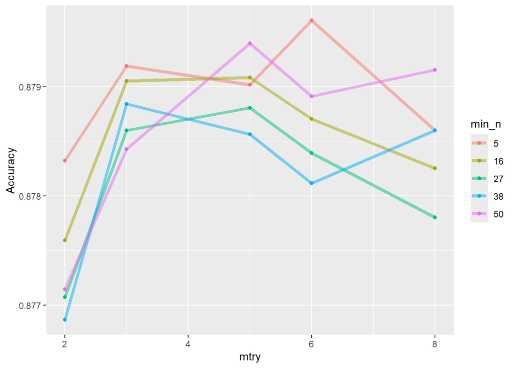

```r
depression_fit %>%
  collect_metrics() %>%
  filter(.metric == "accuracy") %>%
  mutate(min_n = factor(min_n)) %>%
  ggplot(aes(mtry, mean, color = min_n)) +
  geom_line(alpha = 0.5, size = 1.5) +
  geom_point() +
  labs(y = "Accuracy")
```

### Collect the results

```r
rf_best <-
  depression_fit %>%
  select_best(metric = "accuracy")

rf_best
```

```
## # A tibble: 1 × 3
##    mtry min_n .config
##   <int> <int> <chr>
## 1     6     5 pre0_mod16_post0
```

```r
rf_auc_fit <-
  depression_fit %>%
  collect_predictions(parameters = rf_best)

rf_auc_fit
```

```
## # A tibble: 28,830 × 9
##    .pred_class .pred_No .pred_Yes id     depression  .row  mtry min_n .config
##    <fct>          <dbl>     <dbl> <chr>  <fct>      <int> <int> <int> <chr>
##  1 No             0.984    0.0158 Fold01 No            16     6     5 pre0_mod1…
##  2 No             0.925    0.0753 Fold01 Yes           18     6     5 pre0_mod1…
##  3 No             0.866    0.134  Fold01 No            28     6     5 pre0_mod1…
##  4 No             0.953    0.0468 Fold01 No            36     6     5 pre0_mod1…
##  5 Yes            0.435    0.565  Fold01 No            39     6     5 pre0_mod1…
##  6 No             0.946    0.054  Fold01 No            42     6     5 pre0_mod1…
##  7 No             0.856    0.144  Fold01 No            46     6     5 pre0_mod1…
##  8 No             0.875    0.125  Fold01 No            55     6     5 pre0_mod1…
##  9 No             0.955    0.0452 Fold01 No            56     6     5 pre0_mod1…
## 10 No             0.823    0.177  Fold01 Yes           67     6     5 pre0_mod1…
## # ℹ 28,820 more rows
```

### Confusion matrix

Using the class predictions, I will create a confusion matrix to evaluate how the model performed across all the classes.

```r
conf_mat(rf_auc_fit, truth = depression,
         estimate = .pred_class)
```

```
##           Truth
## Prediction    No   Yes
##        No  24860  3096
##        Yes   375   499
```

*Interpretation:* The confusion matrix shows that the model correctly classified 24,860 individuals without depression and 499 individuals with depression. However, 3,096 depression cases were incorrectly predicted as non-depressed (false negatives), indicating that the model misses a substantial number of depression cases. Only 375 non-depressed individuals were incorrectly classified as depressed (false positives).

### Sensitivity

```r
sens(rf_auc_fit, truth = depression,
         estimate = .pred_class)
```

```
## # A tibble: 1 × 3
##   .metric .estimator .estimate
##   <chr>   <chr>          <dbl>
## 1 sens    binary         0.985
```

### Specificity

```r
spec(rf_auc_fit, truth = depression,
         estimate = .pred_class)
```

```
## # A tibble: 1 × 3
##   .metric .estimator .estimate
##   <chr>   <chr>          <dbl>
## 1 spec    binary         0.139
```

### F1 score

```r
f_meas(rf_auc_fit, truth = depression,
         estimate = .pred_class)
```

```
## # A tibble: 1 × 3
##   .metric .estimator .estimate
##   <chr>   <chr>          <dbl>
## 1 f_meas  binary         0.935
```

*Interpretation:* The model achieved an F1 score of 0.93, indicating strong overall performance for the majority class.

## 3. Hyperparameter Tuning Random Forest Model

### Random Forest with Hyperparameter Tuning

```r
rf_best <- depression_fit %>%
  select_best(metric = "accuracy")


final_workflow <- depression_workflow %>%
  finalize_workflow(rf_best)

final_fit <- final_workflow %>%
  last_fit(cv_split)

final_fit
```

```
## # Resampling results
## # Manual resampling
## # A tibble: 1 × 6
##   splits               id              .metrics .notes   .predictions .workflow
##   <list>               <chr>           <list>   <list>   <list>       <list>
## 1 <split [28830/4119]> train/test spl… <tibble> <tibble> <tibble>     <workflow>
```

### Final Tunned Model

```r
final_model <- finalize_model(
                  rf_model,
                  rf_best
                )

final_model
```

```
## Random Forest Model Specification (classification)
##
## Main Arguments:
##   mtry = 6
##   trees = 100
##   min_n = 5
##
## Engine-Specific Arguments:
##   num.threads = cores
##
## Computational engine: ranger
```

### Collecting metrics and predictions from the final model

```r
collect_metrics(final_fit)
```

```
## # A tibble: 3 × 4
##   .metric     .estimator .estimate .config
##   <chr>       <chr>          <dbl> <chr>
## 1 accuracy    binary        0.876  pre0_mod0_post0
## 2 roc_auc     binary        0.739  pre0_mod0_post0
## 3 brier_class binary        0.0987 pre0_mod0_post0
```

```r
final_pred <- collect_predictions(final_fit)

conf_mat(final_pred, truth = depression, estimate = .pred_class)
```

```
##           Truth
## Prediction   No  Yes
##        No  3526  436
##        Yes   73   84
```

```r
accuracy(final_pred, truth = depression, estimate = .pred_class)
```

```
## # A tibble: 1 × 3
##   .metric  .estimator .estimate
##   <chr>    <chr>          <dbl>
## 1 accuracy binary         0.876
```

```r
sens(final_pred, truth = depression, estimate = .pred_class, event_level = "second")
```

```
## # A tibble: 1 × 3
##   .metric .estimator .estimate
##   <chr>   <chr>          <dbl>
## 1 sens    binary         0.162
```

```r
spec(final_pred, truth = depression, estimate = .pred_class, event_level = "second")
```

```
## # A tibble: 1 × 3
##   .metric .estimator .estimate
##   <chr>   <chr>          <dbl>
## 1 spec    binary         0.980
```

```r
f_meas(final_pred, truth = depression, estimate = .pred_class, event_level = "second")
```

```
## # A tibble: 1 × 3
##   .metric .estimator .estimate
##   <chr>   <chr>          <dbl>
## 1 f_meas  binary         0.248
```

```r
roc_auc(final_pred, truth = depression, .pred_Yes, event_level = "second")
```

```
## # A tibble: 1 × 3
##   .metric .estimator .estimate
##   <chr>   <chr>          <dbl>
## 1 roc_auc binary         0.739
```

*Interpretation:* The tuned random forest model achieved an accuracy of 0.876 and ROC-AUC of 0.739, indicating moderate predictive performance. While the model demonstrated high specificity (0.980) in identifying individuals without depression, its sensitivity was low (0.162), meaning that many depression cases were misclassified as non-depressed.

## 4. Model Comparisons

I will now compare the performance of the baseline random forest model and the final tuned model.This comparison will help determine whether hyperparameter tuning has led to a significant improvement in model performance.

```r
baseline_metrics <- collect_metrics(baseline_fit) %>%
  mutate(model = "Baseline RF")

tuned_metrics <- collect_metrics(final_fit) %>%
  mutate(model = "Tuned RF")

comparison_table <- bind_rows(baseline_metrics, tuned_metrics)

comparison_table
```

```
## # A tibble: 6 × 5
##   .metric     .estimator .estimate .config         model
##   <chr>       <chr>          <dbl> <chr>           <chr>
## 1 accuracy    binary        0.877  pre0_mod0_post0 Baseline RF
## 2 roc_auc     binary        0.749  pre0_mod0_post0 Baseline RF
## 3 brier_class binary        0.0971 pre0_mod0_post0 Baseline RF
## 4 accuracy    binary        0.876  pre0_mod0_post0 Tuned RF
## 5 roc_auc     binary        0.739  pre0_mod0_post0 Tuned RF
## 6 brier_class binary        0.0987 pre0_mod0_post0 Tuned RF
```

*Interpretation:* The baseline random forest model performed similarly to the tuned model across all evaluation metrics. The baseline model achieved slightly higher accuracy (0.877 vs. 0.876) and ROC-AUC (0.749 vs. 0.739) and a slightly lower Brier score (0.097 vs. 0.099). Overall, hyperparameter tuning did not meaningfully improve model performance, suggesting that the default baseline configuration already captured most of the predictive signal in the data.

## 5. Feature Importance Analysis

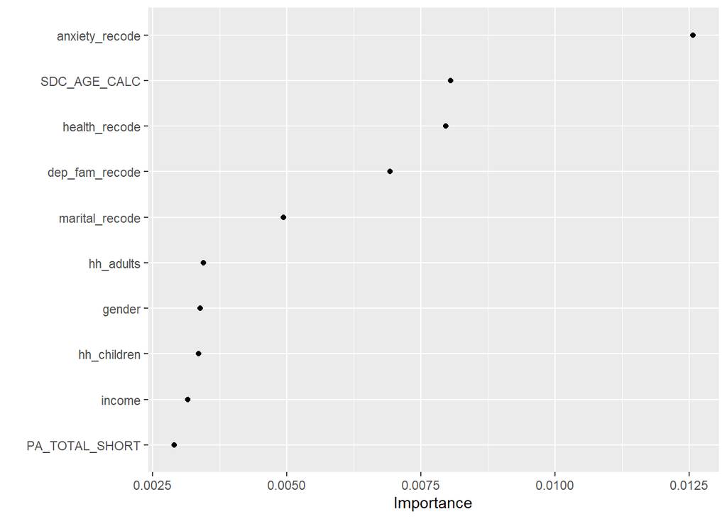

```r
tree_prep <- prep(depression_recipe)

final_model %>%
  set_engine("ranger", importance = "permutation") %>%
  fit(depression ~ .,
    data = juice(tree_prep)) %>%
  vip(geom = "point")
```

*Interpretation:* The feature importance analysis indicates that anxiety status (anxiety_recode) was the most influential predictor of depression in the random forest model. This variable had the highest importance score, suggesting that individuals reporting anxiety were much more likely to be classified as having depression.

Other important predictors included age (SDC_AGE_CALC), self-rated health (health_recode), and family history of depression (dep_fam_recode), all of which showed relatively high importance scores.

Moderately important variables included marital status (marital_recode),gender and, household composition (hh_adults, hh_children).

In contrast, variables such as income, physical activity (PA_TOTAL_SHORT) had lower importance scores, suggesting they contributed less to the predictive performance of the model.